# Text-as-Data-Research – Slides

## Hands-on Methods for Text-as-Data Research

**Artur Baranov, PhD Candidate**  
Department of Political Science, Northwestern University  
artur.baranov@u.northwestern.edu

**Instructions**

1. Open URL (or Scan QR code)
2. Prepare RStudio

Open: artur-baranov.github.io/text-as-data

[figure not shown]

January 20th, 2026

## Motivation (i)

How do government and opposition parties differ in their sentiment in statements on the past, present, and future [(Mueller, 2022)](https://doi.org/10.1086/715165)?

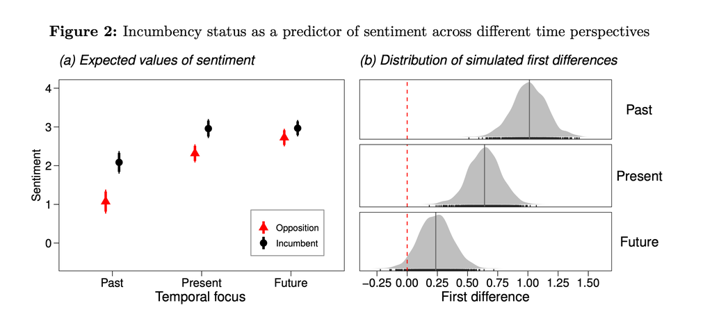

**In the Meantime:**

Open URL & Prepare RStudio

artur-baranov.github.io/text-as-data

## Motivation (ii)

How do autocracies adapt their political messaging during periods of leadership succession [(Boussalis et al, 2023)](https://doi.org/10.1080/10758216.2021.2012199)?

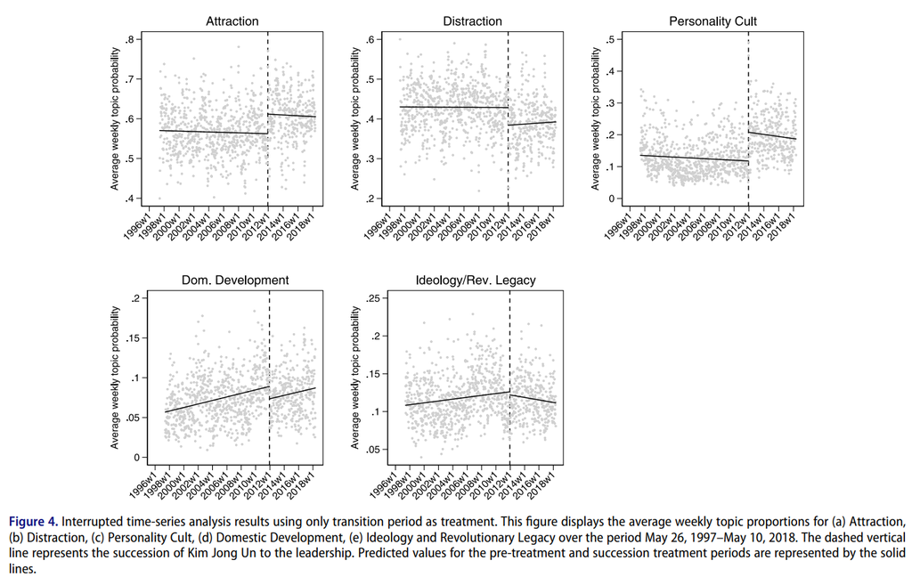

**In the Meantime:**

Open URL & Prepare RStudio

artur-baranov.github.io/text-as-data

## Motivation (iii)

Under what conditions elites “overpraise” the ruler and imitate their rhetoric [(Baturo et al, 2025)](https://doi.org/10.1111/ajps.12909)?

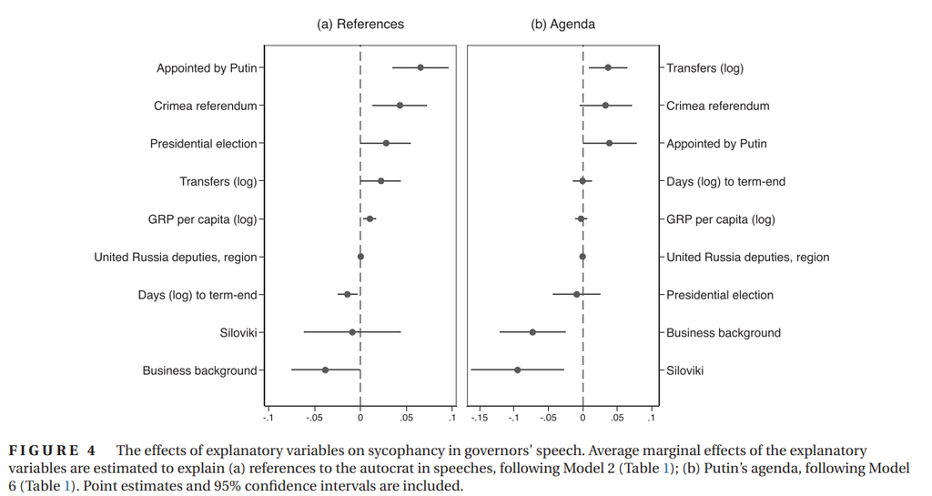

**In the Meantime:**

Open URL & Prepare RStudio

artur-baranov.github.io/text-as-data

## Text Analysis Assumptions

- Texts represent an observable implication of some underlying characteristic of interest
  - An attribute of the author
  - A sentiment or emotion
  - Salience of a political issue
- Texts can be represented through extracting their features
  - Most common is the **bag of words** assumption
  - Many other possible definitions of “features” (e.g. word embeddings)
- A **document-feature matrix** can be analyzed using quantitative methods to produce meaningful and valid estimates of the underlying characteristic of interest

[(Benoit, 2018)](https://kenbenoit.net/assets/courses/tcd2018qta/QTA_TCD_Day1.pdf)

**In the Meantime:**

Open URL & Prepare RStudio

artur-baranov.github.io/text-as-data

## Text Analysis Principles

1. All quantitative models for textual analysis are wrong – but some are useful
2. Quantitative methods for text amplify resources
3. There is no globally best method for automated text analysis
4. Validate, validate, validate (!!!)

[(Grimmer and Stewart, 2013)](https://doi.org/doi:10.1093/pan/mps028)

**In the Meantime:**

Open URL & Prepare RStudio

artur-baranov.github.io/text-as-data

## This Workshop

- is applied
  - follow and execute the code
  - do the exercises
  - ask questions
- focuses on “traditional” QTA methods
  - we will cover AI only briefly
  - otherwise, we have to have another class
- Time to turn to practice

**In the Meantime:**

Open URL & Prepare RStudio

artur-baranov.github.io/text-as-data